# Introduction to Data Visualization with Seaborn

## 4.10 Customizing point plots

Let’s continue to look at data from students in secondary school, this time using a point plot to answer the question: does the quality of the student’s family relationship influence the number of absences the student has in school? Here, we’ll use the “famrel” variable, which describes the quality of a student’s family relationship from 1 (very bad) to 5 (very good).

As a reminder, to create a point plot, use the catplot() function and specify the name of the categorical variable to put on the x-axis (x=____), the name of the quantitative variable to summarize on the y-axis (y=____), the pandas DataFrame to use (data=____), and the type of categorical plot (kind=“point”).

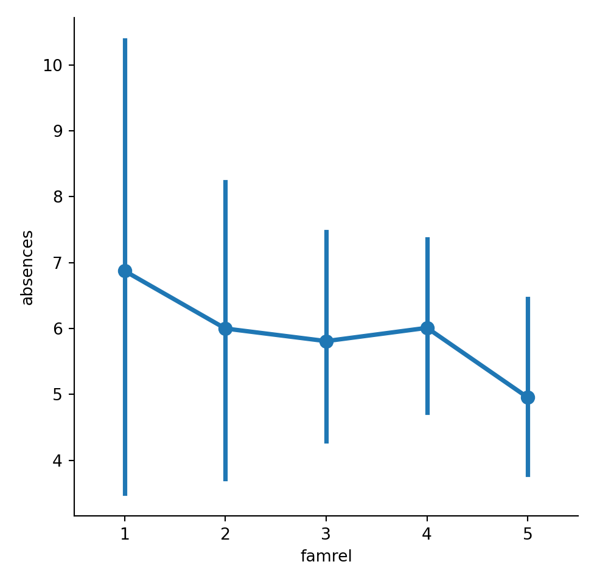

```python
# Create a point plot of family relationship vs. absences
g = sns.catplot(data = student_data, kind = 'point',
                x = "famrel", y = "absences")

# Show plot
plt.show()
```

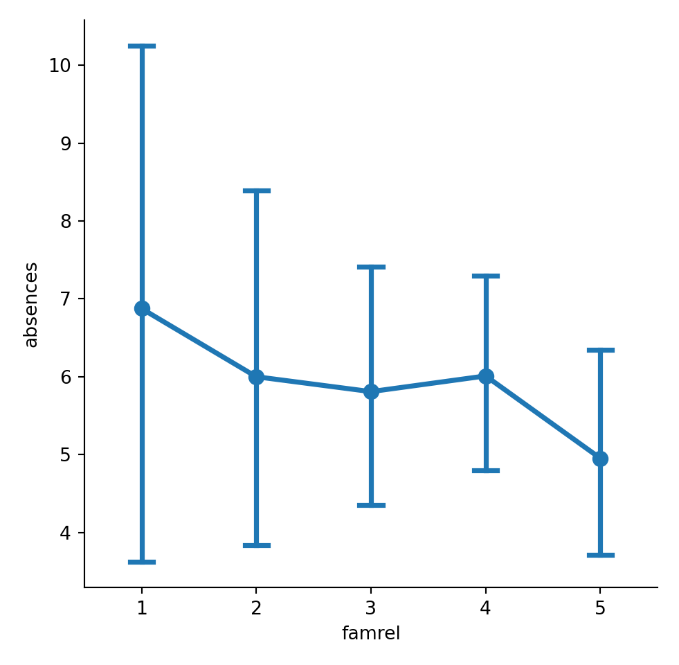

```python
# Add caps to the confidence interval
g = sns.catplot(x = "famrel", y = "absences", data = student_data,
                kind = "point", capsize = 0.2)

# Show plot
plt.show()
```

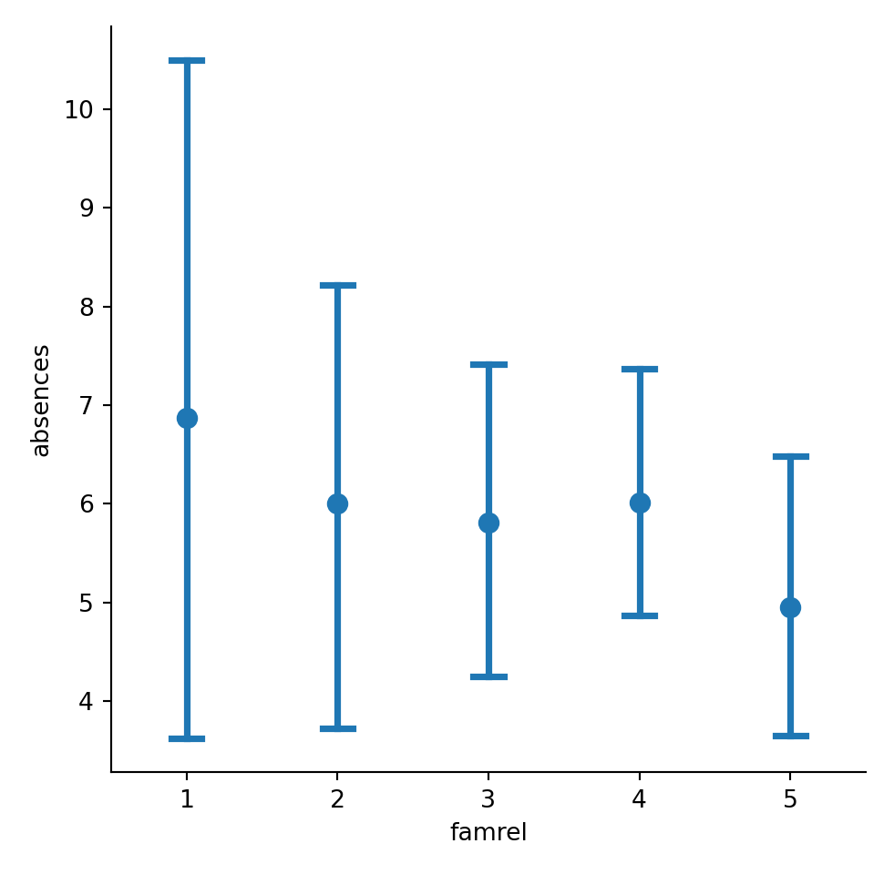

```python
# Remove the lines joining the points
g = sns.catplot(x = "famrel", y = "absences", data = student_data,
                kind = "point", capsize = 0.2, join = False)

# Show plot
plt.show()
```

While the average number of absences is slightly smaller among students with higher-quality family relationships, the large confidence intervals tell us that we can’t be sure there is an actual association here.

## 4.11 Point plots with subgroups

Let’s continue exploring the dataset of students in secondary school. This time, we’ll ask the question: is being in a romantic relationship associated with higher or lower school attendance? And does this association differ by which school the students attend? Let’s find out using a point plot.

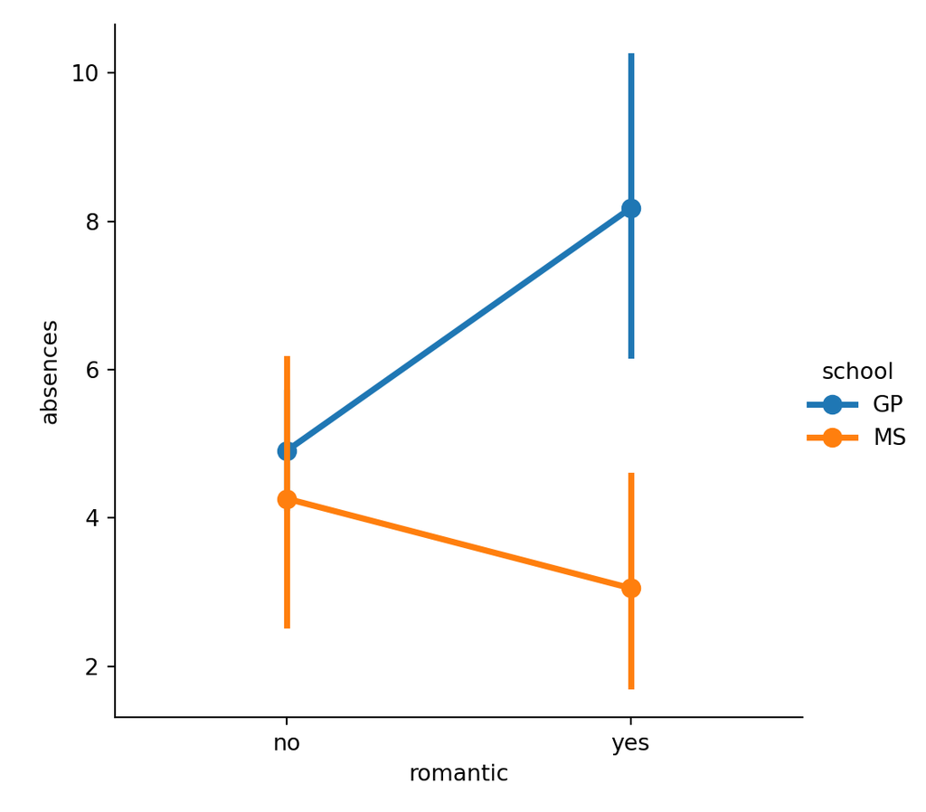

```python
# Create a point plot that uses color to create subgroups
g = sns.catplot(data = student_data, kind = 'point',
                x = "romantic", y = "absences", hue = "school")

# Show plot
plt.show()
```

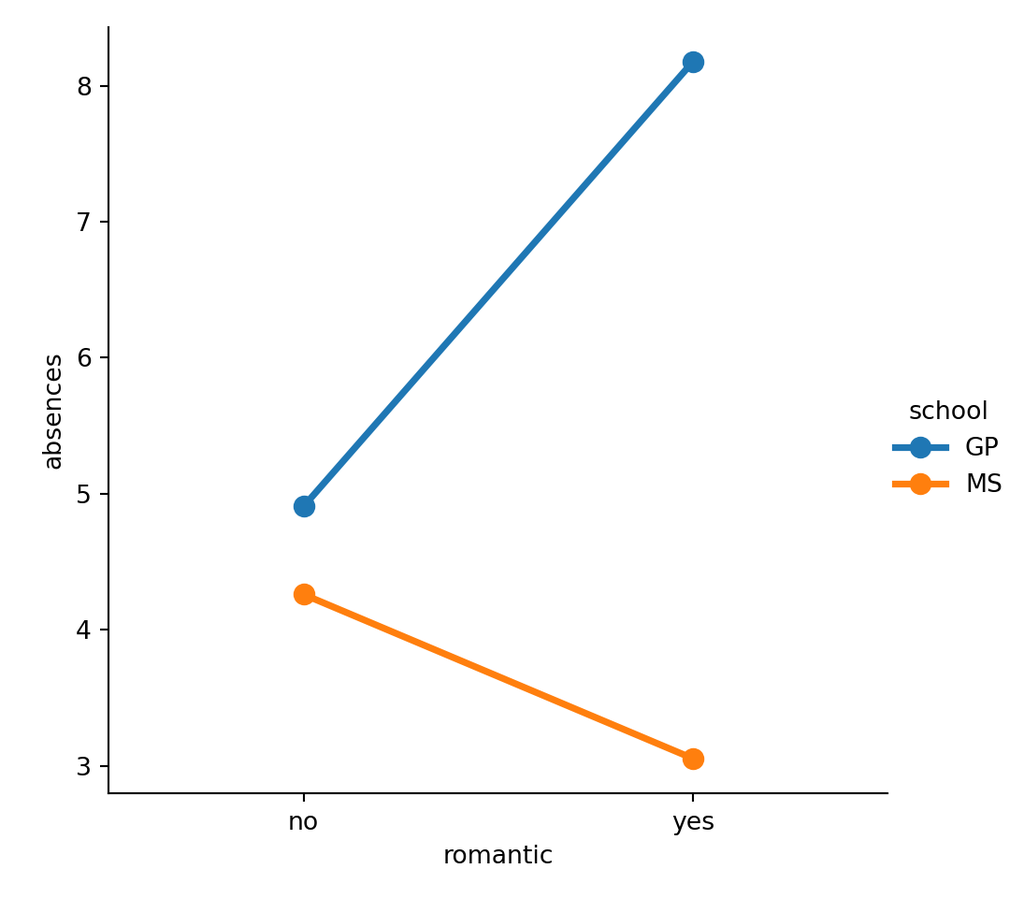

```python
# Turn off the confidence intervals
g = sns.catplot(x = "romantic", y = "absences", data = student_data,
                kind = "point", hue = "school", ci = None)

# Show plot
plt.show()
```

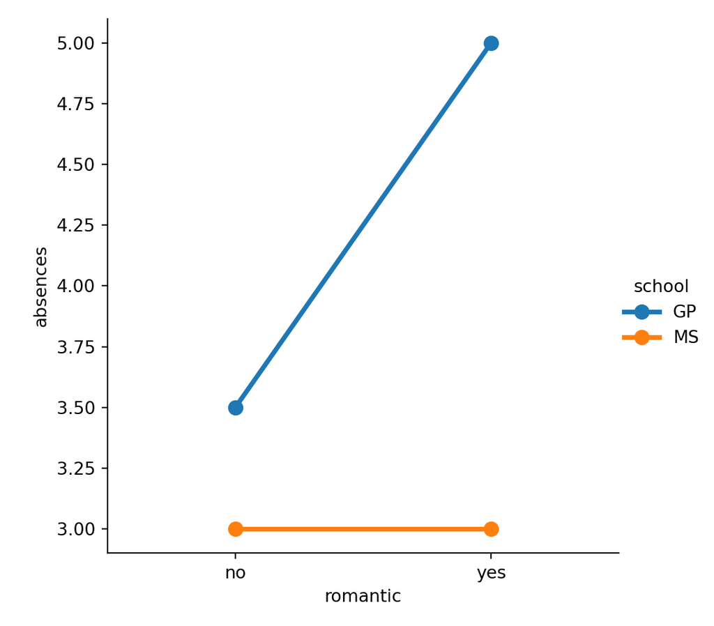

```python
# Import median function from numpy
from numpy import median

# Plot the median number of absences instead of the mean
g = sns.catplot(x = "romantic", y = "absences", data = student_data,
                kind = "point", hue = "school", ci = None, estimator = median)

# Show plot
plt.show()
```

It looks like students in romantic relationships have a higher average and median number of absences in the GP school, but this association does not hold for the MS school.

# 5 Customizing Seaborn Plots

## 5.1 Lecture: Changing plot style and color

[video not shown]

## 5.2 Changing style and palette

Let’s return to our [**dataset** containing the results of a survey given to young people about their habits and preferences. We’ve provided the code to create a count plot of their responses to the question “How often do you listen to your parents’ advice?”. Now let’s change the style and palette to make this plot easier to interpret.](https://raw.githubusercontent.com/QuanNguyenIU/QuanNguyenIU.github.io/main/DataCamp/Python/Intro.%20to%20Data%20Visualization%20with%20Seaborn/survey_data_parent.csv)

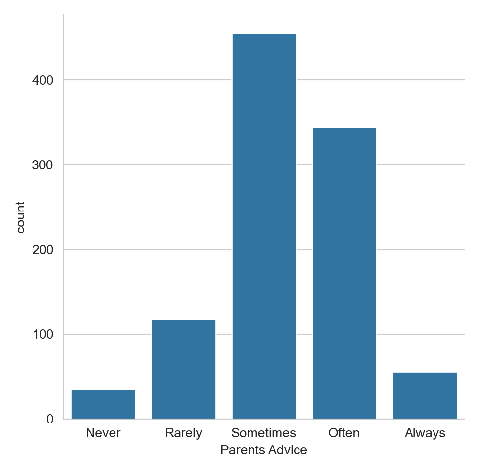

```python
url = 'https://raw.githubusercontent.com/QuanNguyenIU/QuanNguyenIU.github.io/main/DataCamp/Python/Intro.%20to%20Data%20Visualization%20with%20Seaborn/survey_data_parent.csv'
survey_data = pd.read_csv(url)

# Set the style to "whitegrid"
sns.set_style("whitegrid")

# Create a count plot of survey responses
category_order = ["Never", "Rarely", "Sometimes",
                  "Often", "Always"]

g = sns.catplot(x = "Parents Advice", data = survey_data,
                kind = "count", order = category_order)

# Show plot
plt.show()
```

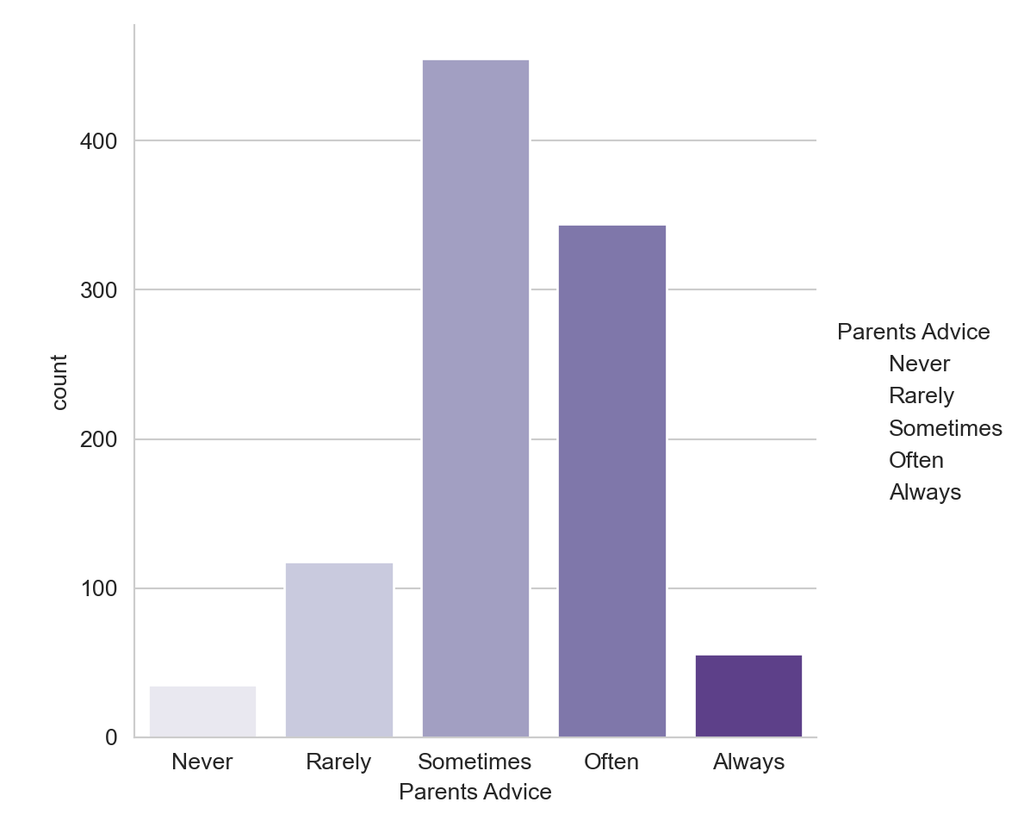

```python
# Set the color palette to "Purples"
sns.set_style("whitegrid")


# Create a count plot of survey responses
category_order = ["Never", "Rarely", "Sometimes",
                  "Often", "Always"]

g = sns.catplot(x = "Parents Advice", data = survey_data,
                kind = "count", order = category_order, palette = "Purples")

# Show plot
plt.show()
```

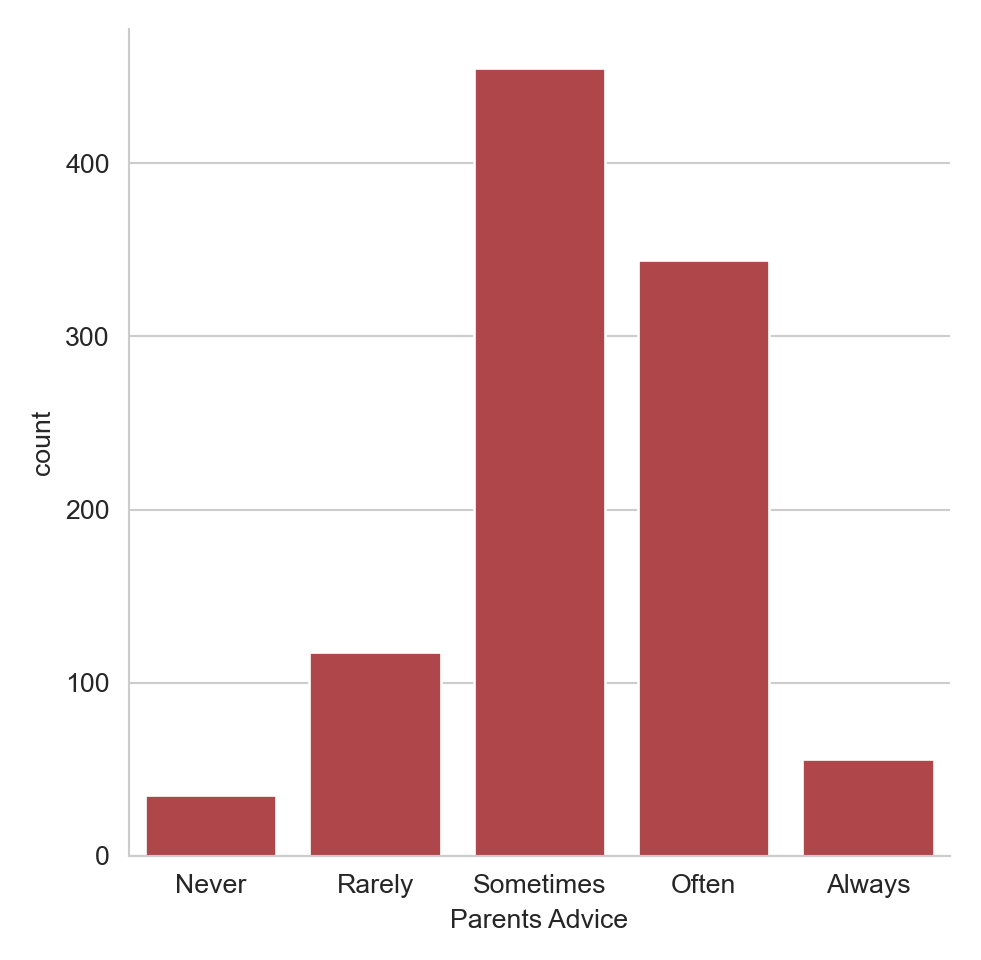

```python
# Change the color palette to "RdBu"
sns.set_style("whitegrid")
sns.set_palette("RdBu")

# Create a count plot of survey responses
category_order = ["Never", "Rarely", "Sometimes",
                  "Often", "Always"]

g = sns.catplot(x = "Parents Advice", data = survey_data,
                kind = "count", order = category_order)

# Show plot
plt.show()
```

## 5.3 Changing the scale

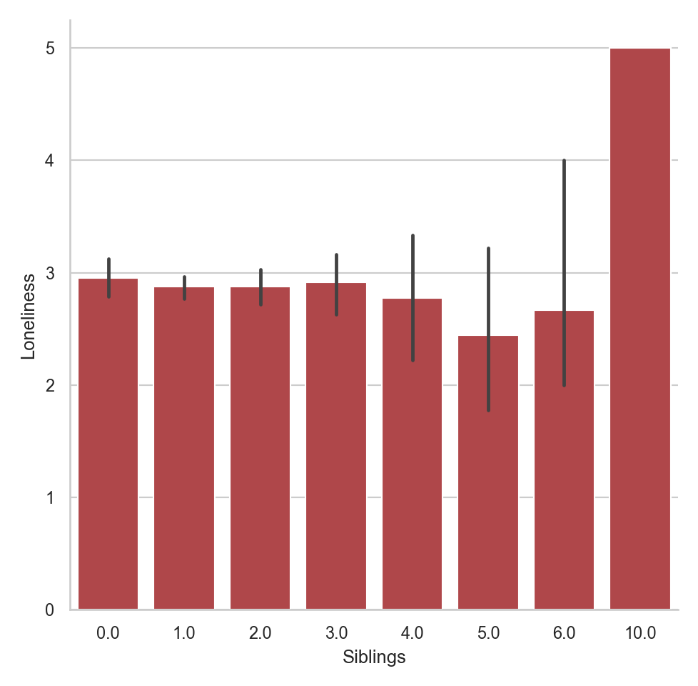

```python
# Set the context to "paper"
sns.set_context("paper")

# Create bar plot
g = sns.catplot(x = "Siblings", y = "Loneliness",
                data = survey_data, kind = "bar")

# Show plot
plt.show()
```

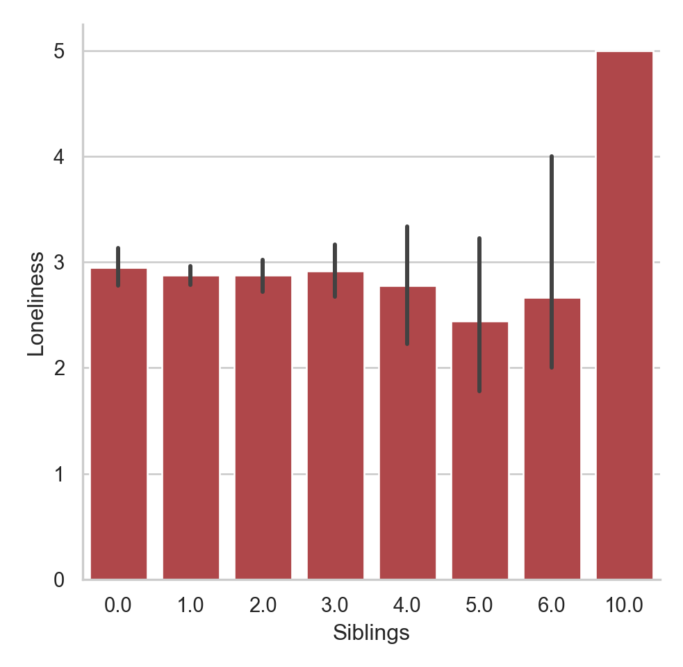

```python
# Change the context to "notebook"
sns.set_context("notebook")

# Create bar plot
g = sns.catplot(x = "Siblings", y = "Loneliness",
                data = survey_data, kind = "bar")

# Show plot
plt.show()
```

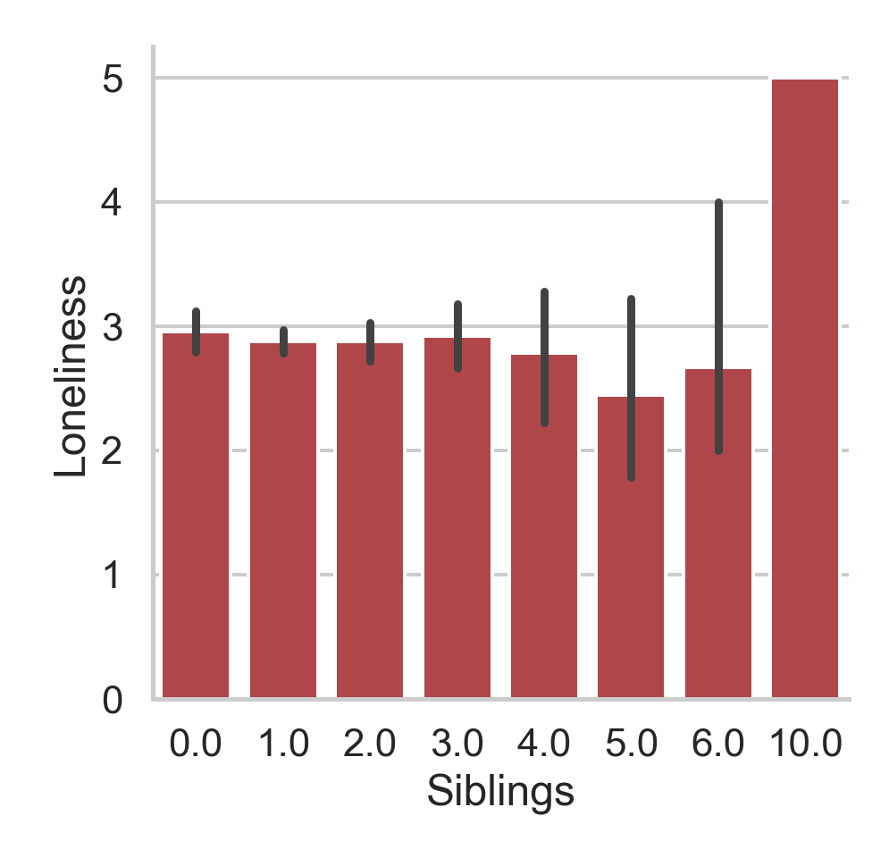

```python
# Change the context to "talk"
sns.set_context("talk")

# Create bar plot
g = sns.catplot(x = "Siblings", y = "Loneliness",
                data = survey_data, kind = "bar")

# Show plot
plt.show()
```

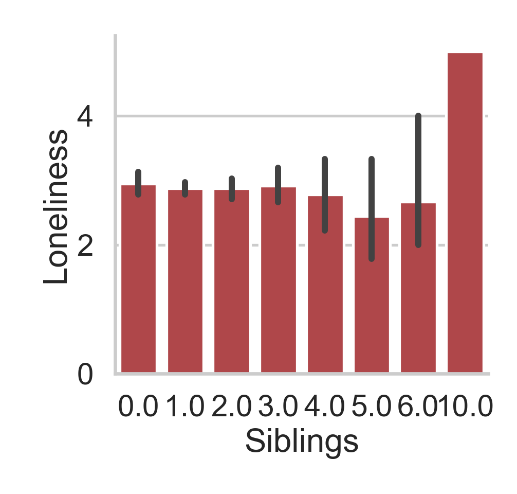

```python
# Change the context to "poster"
sns.set_context("poster")

# Create bar plot
g = sns.catplot(x = "Siblings", y = "Loneliness",
                data = survey_data, kind = "bar")

# Show plot
plt.show()
```

Each context name gives Seaborn’s suggestion on when to use a given plot scale (in a paper, in an iPython notebook, in a talk/presentation, or in a poster session).

## 5.4 Using a custom palette

So far, we’ve looked at several things in the dataset of survey responses from young people, including their internet usage, how often they listen to their parents, and how many of them report feeling lonely. However, one thing we haven’t done is a basic summary of the type of people answering this survey, including their age and gender. Providing these basic summaries is always a good practice when dealing with an unfamiliar dataset.

The code provided will create a box plot showing the distribution of ages for male versus female respondents. Let’s adjust the code to customize the appearance, this time using a custom color palette.

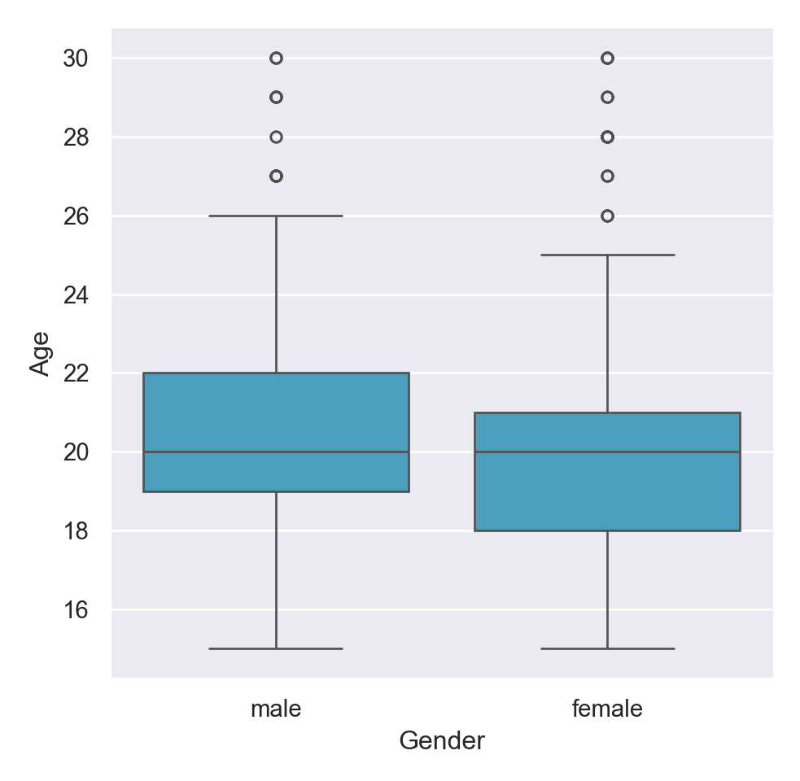

```python
# Set the style to "darkgrid"
sns.set_style("darkgrid")

# Set a custom color palette
sns.set_palette(["#39A7D0", "#36ADA4"])

# Create the box plot of age distribution by gender
g = sns.catplot(x = "Gender", y = "Age",
                data = survey_data, kind = "box")

# Show plot
plt.show()
```

It looks like the median age is the same for males and females, but distribution of females skews younger than the males.

## 5.5 Lecture: Adding titles and labels: Part 1

[video not shown]

## 5.6 FacetGrids vs. AxesSubplots

In the recent lesson, we learned that Seaborn plot functions create two different types of objects: FacetGrid objects and AxesSubplot objects. The method for adding a title to your plot will differ depending on the type of object it is.

In the code provided, we’ve used relplot() with the miles per gallon dataset to create a scatter plot showing the relationship between a car’s weight and its horsepower. This scatter plot is assigned to the variable name g. Let’s identify which type of object it is.

```
## <class 'seaborn.axisgrid.FacetGrid'>
```

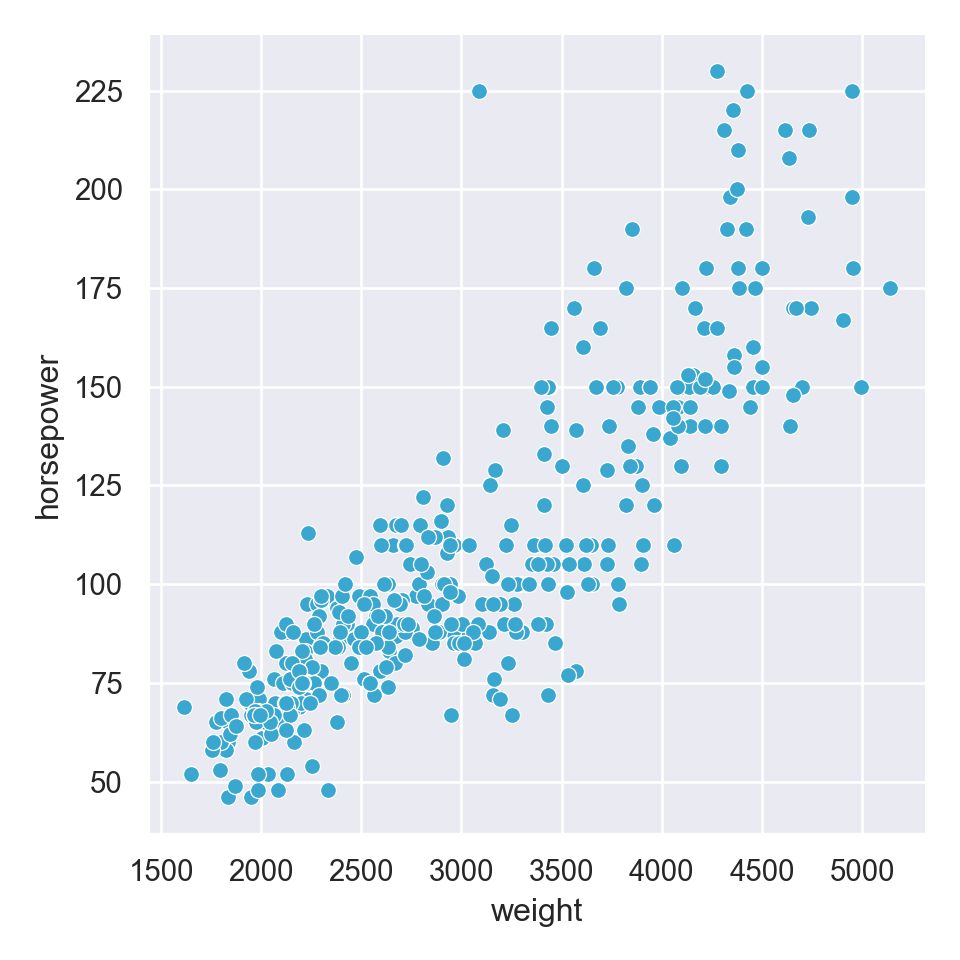

```python
# Create scatter plot
g = sns.relplot(x = "weight", y = "horsepower",
                data = mpg, kind = "scatter")

# Identify plot type
type_of_g = type(g)

# Print type
print(type_of_g)
```

Beside relplot(), catplot() supports creating subplots, so it also creates a FacetGrid object.

## 5.7 Adding a title to a FacetGrid object

In the previous exercise, we used relplot() with the miles per gallon dataset to create a scatter plot showing the relationship between a car’s weight and its horsepower. This created a FacetGrid object. Now that we know what type of object it is, let’s add a title to this plot.

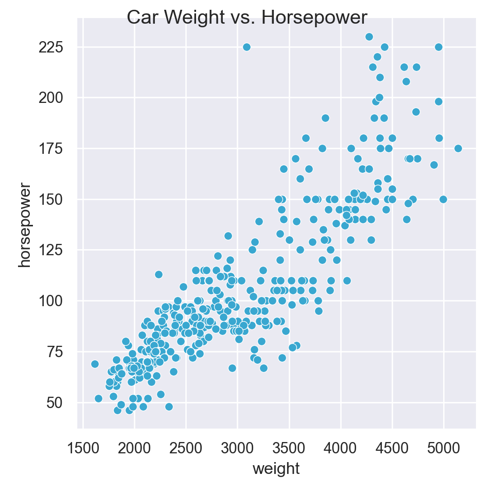

```python
# Create scatter plot
g = sns.relplot(x = "weight", y = "horsepower",
                data = mpg, kind = "scatter")

# Add a title "Car Weight vs. Horsepower"
g.fig.suptitle("Car Weight vs. Horsepower")

# Show plot
plt.show()
```

It looks like a car’s weight is positively correlated with its horsepower.

## 5.8 Lecture: Adding titles and labels: Part 2

[video not shown]

## 5.9 Adding a title and axis labels

Let’s continue to look at the [**miles per gallon dataset**. This time we’ll create a line plot to answer the question: How does the average miles per gallon achieved by cars change over time for each of the three places of origin? To improve the readability of this plot, we’ll add a title and more informative axis labels.](https://raw.githubusercontent.com/QuanNguyenIU/QuanNguyenIU.github.io/main/DataCamp/Python/Intro.%20to%20Data%20Visualization%20with%20Seaborn/mpg_mean.csv)

In the code provided, we create the line plot using the lineplot() function. Note that lineplot() does not support the creation of subplots, so it returns an AxesSubplot object instead of an FacetGrid object.

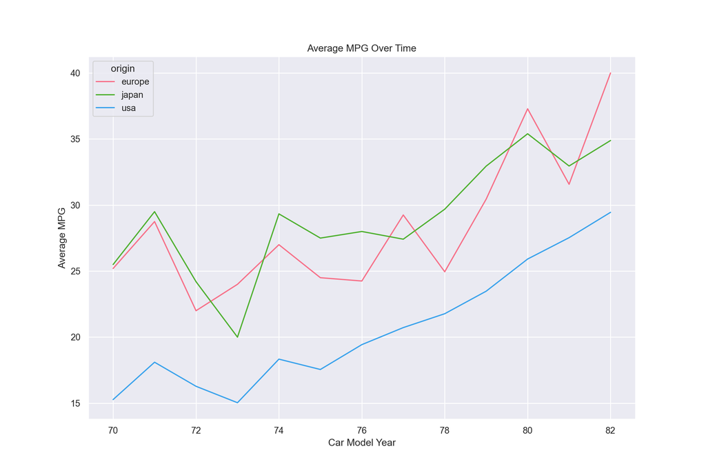

```python
url = 'https://raw.githubusercontent.com/QuanNguyenIU/QuanNguyenIU.github.io/main/DataCamp/Python/Intro.%20to%20Data%20Visualization%20with%20Seaborn/mpg_mean.csv'
mpg_mean = pd.read_csv(url, sep = ';')

# Create line plot
g = sns.lineplot(x = "model_year", y = "mpg_mean",
                 data = mpg_mean, hue = "origin")

# Add a title "Average MPG Over Time"
g.set_title("Average MPG Over Time")

# Add x-axis and y-axis labels
g.set(xlabel = "Car Model Year",ylabel = "Average MPG")


# Show plot
plt.show()
```

## 5.10 Rotating x-tick labels

In this exercise, we’ll continue looking at the miles per gallon dataset. In the code provided, we create a point plot that displays the average acceleration for cars in each of the three places of origin. Note that the “acceleration” variable is the time to accelerate from 0 to 60 miles per hour, in seconds. Higher values indicate slower acceleration.

Let’s use this plot to practice rotating the x-tick labels. Recall that the function to rotate x-tick labels is a standalone Matplotlib function and not a function applied to the plot object itself.

```python
# Create point plot
g = sns.catplot(x = "origin", y = "acceleration", data = mpg,
                kind = "point", join = False, capsize = 0.1)

# Rotate x-tick labels
plt.xticks(rotation = 90)
```

```
## ([0, 1, 2], [Text(0, 0, 'usa'), Text(1, 0, 'japan'), Text(2, 0, 'europe')])
```

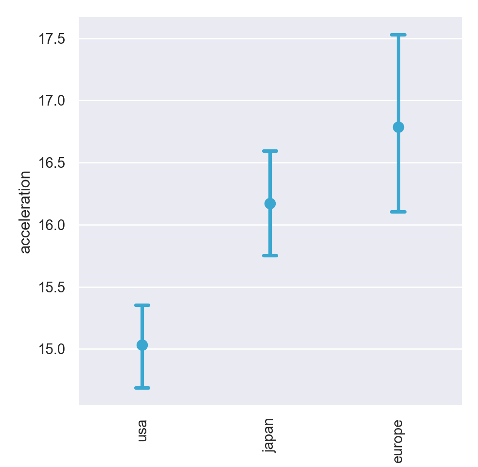

```python
# Show plot
plt.show()
```

## 5.11 Lecture: Putting it all together

[video not shown]

## 5.12 Box plot with subgroups

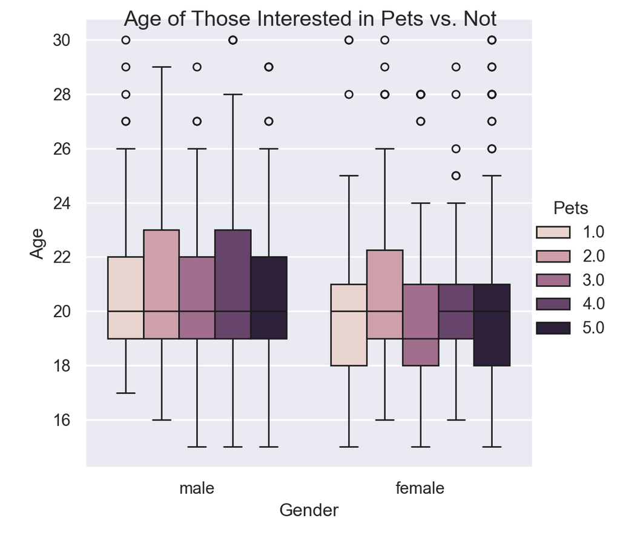

```python
# Set palette to "Blues"
sns.set_palette("Blues")

# Adjust to add subgroups based on "Pets"
g = sns.catplot(x = "Gender", y = "Age", data = survey_data,
                kind = "box", hue = "Pets")

# Set title to "Age of Those Interested in Pets vs. Not"
g.fig.suptitle("Age of Those Interested in Pets vs. Not")

# Show plot
plt.show()
```

## 5.13 Bar plot with subgroups and subplots

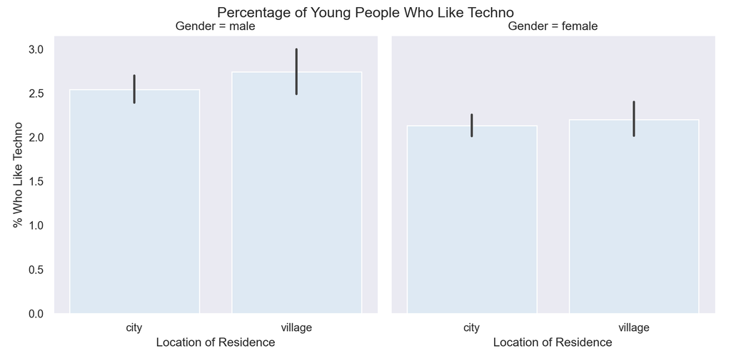

```python
# Set the figure style to "dark"
sns.set_style("dark")

# Adjust to add subplots per gender
g = sns.catplot(x = "Village - town", y = "Techno", data = survey_data,
                kind = "bar", col = "Gender")

# Add title and axis labels
g.fig.suptitle("Percentage of Young People Who Like Techno")
g.fig.subplots_adjust(top = 0.9)
f = g.set(xlabel = "Location of Residence",
          ylabel = "% Who Like Techno")

# Show plot
plt.show()
```

# 6 Course Recap

[video not shown]

Congratulations on completing the course! More courses, tracks and instructions can be found [**here**. Happy learning!](https://quannguyeniu.github.io/DataCamp/master.html)